# Homework #1: Eastern Box Turtles

25 points - Due Wednesday 1/26 at 5:00pm

**Directions:** This first assignment is meant to be a brief introduction to working with R in RStudio. You may (and should) collaborate with other students. If you do so, you must identify them on the work that you turn in. You should complete the assignment in an R Notebook, including all calculations, plots, and explanations. Make use of the white space outside of the R chunks for your explanations rather than using comments inside of the chunks. For your submission, you should knit the notebook to PDF and submit the file to Gradescope.

**Eastern Box Turtles:** The Box Turtle Connection is a long-term study anticipating at least 100 years of data collection on box turtles. Their purpose is to learn more about the status and trends in box turtle populations, identify threats, and develop strategies for long-term conservation of the species. Eastern Box Turtle populations are in decline in North Carolina and while they are recognized as a threatened species by the International Union for Conservation of Nature, the turtles have no protection in North Carolina. There are currently more than 30 active research study sites across the state of North Carolina. Turtles are weighed, measured, photographed, and permanently marked. These data, along with voucher photos (photos that document sightings), are then entered into centralized database managed by the NC Wildlife Resources Commission. The *Turtles* dataset (found at the link below) contains data collected at The Piedmont Wildlife Center in Durham.

https://raw.githubusercontent.com/JA-McLean/STOR455/master/data/Turtles.csv

1. The *Annuli* rings on a turtle represent growth on the scutes of the carapace and plastron. In the past, it was thought that annuli corresponded to age, but recent findings suggest that this is not the case. However, the annuli are still counted since it may yield important life history information. Construct a least squares regression line that predicts turtles’ *Annuli* by their *Mass*.
2. Produce a scatterplot of this relationship (and include the least squares line on the plot).
3. The turtle in the 40th row of the *Turtles* dataset has a mass of 390 grams. What does your model predict for this turtle’s number of *Annuli*? What is the residual for this case?
4. Which turtle (by row number in the dataset) has the largest positive residual? What is the value of that residual?
5. Which turtle (by row number in the dataset) has the most negative residual? What is the value of that residual?
6. Comment on how each of the conditions for a simple linear model are (or are not) met in this model. Include at least two plots (in addition to the plot in question 2) - with commentary on what each plot tells you specifically about the appropriateness of conditions.
7. Experiment with at least two transformations to determine if models constructed with these transformations appear to do a better job of satisfying each of the simple linear model conditions. Include the summary outputs for fitting these models and scatterplots of the transformed variable(s) with the least square lines.
8. For your model with the best transformation from question 7 (It still may not be an ideal model), plot the raw data (not transformed) with the model (likely a curve) on the same axes.
9. Again, the turtle in the 40th row of the *Turtles* dataset has a mass of 390 grams. For your model using the best transformation from question 7, what does this model predict for this turtle’s number of *Annuli*? In terms of *Annuli*, how different is this prediction from the observed value?
10. For your model using the best transformation from question 7, could the relationship between *Mass* and *Annuli* be different depending on the *LifeStage* and *Sex* of the turtle? Construct two new dataframes, one with only adult male turtles, and one with only adult female turtles. Using your best transformation from question 7, construct two new models to predict *Annuli* with *Mass* for adult male and adult female turtles separately. Plot the raw data for *Anulli* and *Mass* for all adult turtles as well as each of these new models on the same plot. You should use different colors for each model (which are likely curves). What does this plot tell you about the relationship between *Mass* and *Annuli* depending on the *Sex* of adult turtles?

```r
library(readr)
library(Stat2Data)

Turtles <- read_csv(
  "https://raw.githubusercontent.com/JA-McLean/STOR455/master/data/Turtles.csv")
```

# Q1&2:

a least squares regression line & a scatterplot

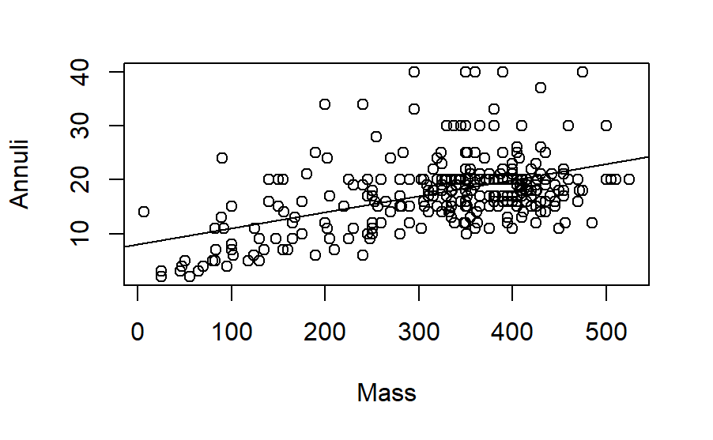

```r
plot(Annuli~Mass, data=Turtles)
Turtlesmod1 =lm(Annuli~Mass, data=Turtles)
abline(Turtlesmod1)
```

# Q3:

```r
Turtlesmod1$resid[40]
```

```
      40
20.38223
```

```r
390-Turtlesmod1$resid[40]
```

```
      40
369.6178
```

# Q4&5:

row185 has the largest positive residual. The value is 23.19151. row93 has the most negative residual. The value is -10.42705.

```r
max(Turtlesmod1$residuals)
```

```
[1] 23.19151
```

```r
which.max(Turtlesmod1$residuals)
```

```
185
185
```

```r
Turtles[185,]
```

| LifeStage | Sex | Annuli | Mass | StraightlineCL | MaxCW | PL_AnteriortoHinge | PL_HingetoPosterior | ShellHeightatHinge |
| --- | --- | --- | --- | --- | --- | --- | --- | --- |
| Adult | Female | 40 | 295 | 109 | 85 | 44 | 64 | 61 |

```r
min(Turtlesmod1$residuals)
```

```
[1] -10.42705
```

```r
which.min(Turtlesmod1$residuals)
```

```
93
93
```

```r
Turtles[93,]
```

| LifeStage | Sex | Annuli | Mass | StraightlineCL | MaxCW | PL_AnteriortoHinge | PL_HingetoPosterior | ShellHeightatHinge |
| --- | --- | --- | --- | --- | --- | --- | --- | --- |
| Adult | Female | 12 | 485 | 129.2 | 104.82 | 52.59 | 79.27 | 65.09 |

# Q6:

Simple Linear Model-Conditions (1)Linearity: Not good. From the residuals vs Fitted plot, we can see that the data does not follow the horizontal line centered at 0, and the red line shows another pattern. (2)Zero Mean: No problem. This is inherent using the least squares method. (3)Constant variance(Homoscedasticity): Not good. From the lm picture(Q2), we know that there is a fanning pattern in most of the back place. (4)Independence:Uncertain. Turtles’ annulis may not have internal influence. But we do not know the time and process of data collection. (5)Normality:not good nor bad. From the NormalQQ, data at both tail fly out, althouth the sample size is not large enough(307 observations).

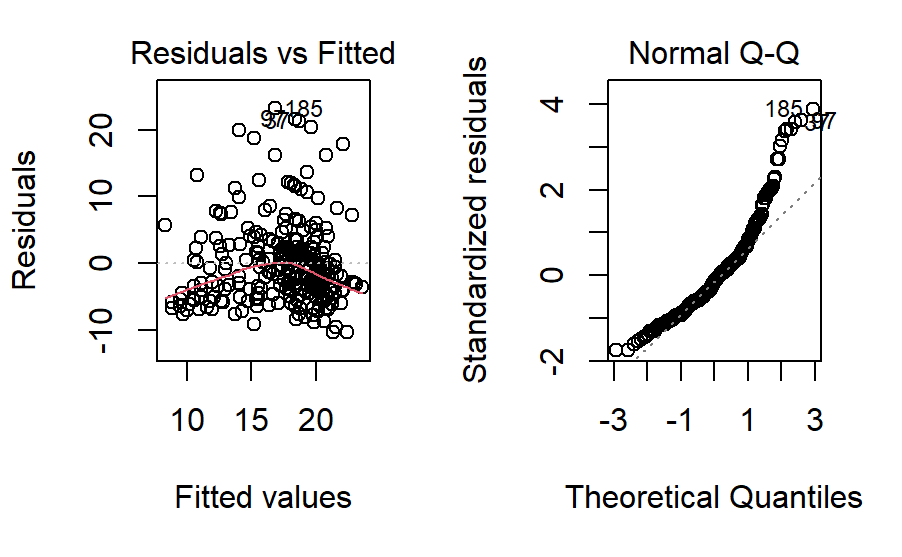

```r
par(mfrow=c(1,2))
plot(Turtlesmod1,1:2)
```

# Q7.1:

Logarithmic linear transformation By comparing 4 log-linear plots, I think double-log is the best. Due to the piled up data is not clear, I made a subset for easy viewing. Overall the new model is better. Linearity improves(residuals vs Fitted better). The constant variance improves(no fanning pattern). Normality improves(NormalQQ better).

```r
par(mfrow=c(2,2))

plot(Annuli~Mass, data=Turtles)
plot(log(Annuli)~Mass, data=Turtles)
```

```r
plot(Annuli~log(Mass), data=Turtles)
plot(log(Annuli)~log(Mass), data=Turtles)
```

[figure not shown]

```r
par(mfrow=c(1,3))
```

```r
Turtle_above_200mass = subset(Turtles, Mass > 200)
Turtlesmod2 =lm(log(Annuli)~log(Mass), data=Turtle_above_200mass)

plot(log(Annuli)~log(Mass), Turtle_above_200mass)
abline(Turtlesmod2)
```

[figure not shown]

```r
plot(Turtlesmod2,1:2)
```

[output not shown]

```r
summary(Turtlesmod2)
```

```
Call:
lm(formula = log(Annuli) ~ log(Mass), data = Turtle_above_200mass)

Residuals:
     Min       1Q   Median       3Q      Max
-0.95872 -0.16297 -0.00392  0.12972  0.86011

Coefficients:
            Estimate Std. Error t value Pr(>|t|)
(Intercept)  0.67103    0.52349   1.282    0.201
log(Mass)    0.37942    0.08906   4.260 2.87e-05 ***
---
Signif. codes:
0 ‘***’ 0.001 ‘**’ 0.01 ‘*’ 0.05 ‘.’ 0.1 ‘ ’ 1

Residual standard error: 0.2888 on 256 degrees of freedom
Multiple R-squared:  0.0662,    Adjusted R-squared:  0.06255
F-statistic: 18.15 on 1 and 256 DF,  p-value: 2.872e-05
```

# Q7.2:

Power function transformation Overall the new model is not good. Linearity worse(residuals vs Fitted do not improve). The constant variance do not improve. Normality not good nor bad still.

```r
par(mfrow=c(1,3))

Turtlesmod3=lm(Annuli~I(Mass^3), data=Turtles)

plot(Annuli~I(Mass^3), data=Turtles)
abline(Turtlesmod3)
```

[figure not shown]

```r
plot(Turtlesmod3,1:2)
```

[output not shown]

```r
summary(Turtlesmod3)
```

```
Call:
lm(formula = Annuli ~ I(Mass^3), data = Turtles)

Residuals:
     Min       1Q   Median       3Q      Max
-12.0165  -4.2487  -0.7968   2.7762  23.8992

Coefficients:
             Estimate Std. Error t value Pr(>|t|)
(Intercept) 1.400e+01  6.352e-01  22.043  < 2e-16 ***
I(Mass^3)   8.172e-08  1.170e-08   6.985 1.79e-11 ***
---
Signif. codes:
0 ‘***’ 0.001 ‘**’ 0.01 ‘*’ 0.05 ‘.’ 0.1 ‘ ’ 1

Residual standard error: 6.323 on 305 degrees of freedom
Multiple R-squared:  0.1379,    Adjusted R-squared:  0.1351
F-statistic:  48.8 on 1 and 305 DF,  p-value: 1.787e-11
```

# Q8:

the raw data with the double-log model

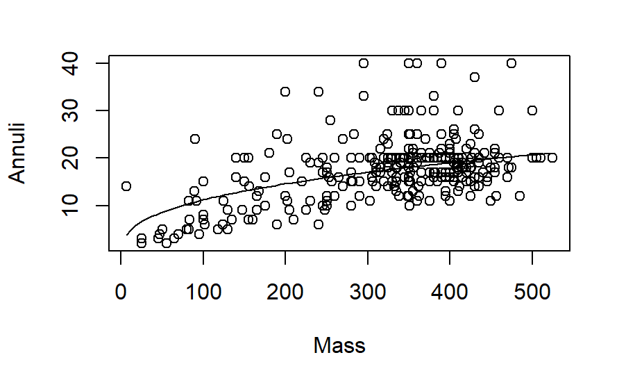

```r
B0 = summary(Turtlesmod2)$coefficients[1,1]
B1 = summary(Turtlesmod2)$coefficients[2,1]

plot(Annuli~Mass, data=Turtles)
curve(exp(B0)*x^B1, add=TRUE)
```

# Q9:

```r
Turtlesmod2$resid[40]
```

```
       40
0.2101058
```

```r
390-Turtlesmod2$resid[40]
```

```
      40
389.7899
```

# Q10:

new exploration the relationship between Mass and Annuli is probably positive correlation. The increasing speed of female turtles’ annulis is faster than the males’.

```r
Turtles_adult =subset(Turtles,LifeStage=='Adult')
Turtles_adult_male =subset(Turtles_adult,Sex=='Male')
Turtles_adult_female =subset(Turtles_adult,Sex=='Female')

Turtlesmod_male =lm(log(Annuli)~log(Mass), data=Turtles_adult_male)
Turtlesmod_female =lm(log(Annuli)~log(Mass), data=Turtles_adult_female)

B0 = summary(Turtlesmod_male)$coefficients[1,1]
B1 = summary(Turtlesmod_male)$coefficients[2,1]
B2 = summary(Turtlesmod_female)$coefficients[1,1]
B3 = summary(Turtlesmod_female)$coefficients[2,1]

plot(Annuli~Mass, data=Turtles_adult)
curve(exp(B0)*x^B1, col='blue',add=TRUE)
```

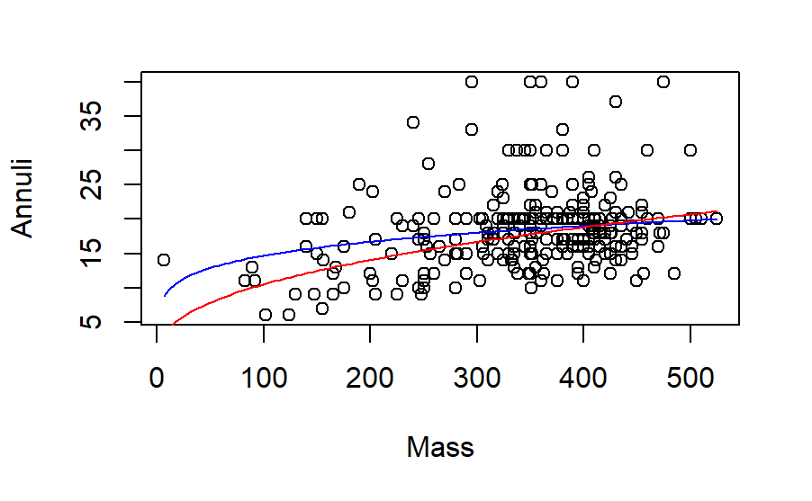

```r
curve(exp(B2)*x^B3, col='red',add=TRUE)
```